# Homework 3

## Task 4

```r
super <- read.csv ("https://blue.butler.edu/~rpadgett/ps310/Data/Supermodel.csv",
      header= TRUE)
library(psych)
describe(super)
```

```
##        vars   n  mean    sd median trimmed  mad   min   max range skew kurtosis
## salary    1 231 11.34 16.03   4.82    7.91 6.70  0.00 95.34 95.34 2.46     7.18
## age       2 231 18.07  2.42  18.01   17.97 1.99 12.17 25.29 13.12 0.36     0.29
## years     3 231  4.59  1.58   4.49    4.53 1.24  0.43  9.93  9.50 0.34     0.47
## beauty    4 231 75.94  6.77  76.57   75.98 5.51 58.13 99.22 41.09 0.00     0.41
##          se
## salary 1.05
## age    0.16
## years  0.10
## beauty 0.45
```

```r
library (olsrr)
mod6 <- lm(salary~age+years+beauty, data=super)
ols_regress(mod6)
```

```
##                           Model Summary
## -----------------------------------------------------------------
## R                        0.429       RMSE                 14.445
## R-Squared                0.184       MSE                 212.347
## Adj. R-Squared           0.173       Coef. Var           128.520
## Pred R-Squared           0.149       AIC                1899.264
## MAE                     10.195       SBC                1916.476
## -----------------------------------------------------------------
##  RMSE: Root Mean Square Error
##  MSE: Mean Square Error
##  MAE: Mean Absolute Error
##  AIC: Akaike Information Criteria
##  SBC: Schwarz Bayesian Criteria
##
##                                 ANOVA
## ----------------------------------------------------------------------
##                  Sum of
##                 Squares         DF    Mean Square      F         Sig.
## ----------------------------------------------------------------------
## Regression    10871.964          3       3623.988    17.066    0.0000
## Residual      48202.790        227        212.347
## Total         59074.754        230
## ----------------------------------------------------------------------
##
##                                     Parameter Estimates
## -------------------------------------------------------------------------------------------
##       model       Beta    Std. Error    Std. Beta      t        Sig       lower      upper
## -------------------------------------------------------------------------------------------
## (Intercept)    -60.890        16.497                 -3.691    0.000    -93.396    -28.384
##         age      6.234         1.411        0.942     4.418    0.000      3.454      9.015
##       years     -5.561         2.122       -0.548    -2.621    0.009     -9.743     -1.380
##      beauty     -0.196         0.152       -0.083    -1.289    0.199     -0.497      0.104
## -------------------------------------------------------------------------------------------
```

```r
summary(mod6)
```

```
##
## Call:
## lm(formula = salary ~ age + years + beauty, data = super)
##
## Residuals:
##     Min      1Q  Median      3Q     Max
## -24.853  -7.950  -4.197   4.605  68.085
##
## Coefficients:
##             Estimate Std. Error t value Pr(>|t|)
## (Intercept) -60.8897    16.4966  -3.691  0.00028 ***
## age           6.2344     1.4112   4.418 1.54e-05 ***
## years        -5.5612     2.1222  -2.621  0.00937 **
## beauty       -0.1964     0.1524  -1.289  0.19871
## ---
## Signif. codes:  0 '***' 0.001 '**' 0.01 '*' 0.05 '.' 0.1 ' ' 1
##
## Residual standard error: 14.57 on 227 degrees of freedom
## Multiple R-squared:  0.184,  Adjusted R-squared:  0.1733
## F-statistic: 17.07 on 3 and 227 DF,  p-value: 4.973e-10
```

Based on this output, age is a significant predictor of a model’s salary. Looking at the beta, this is a positive relationship meaning that as a model’s age increases, their salary increases. Years of experience or years of being a model is also a significant predictor, but it is a negative relationship. This means that as years goes up, the model’s salary decreases. From this model we also see that beauty is not a significant predictor of a model’s salary.

```r
library (olsrr)
mod7 <- lm(salary~years, data=super)
ols_regress(mod7)
```

```
##                           Model Summary
## -----------------------------------------------------------------
## R                        0.337       RMSE                 15.054
## R-Squared                0.114       MSE                 228.613
## Adj. R-Squared           0.110       Coef. Var           133.351
## Pred R-Squared           0.089       AIC                1914.340
## MAE                     10.646       SBC                1924.667
## -----------------------------------------------------------------
##  RMSE: Root Mean Square Error
##  MSE: Mean Square Error
##  MAE: Mean Absolute Error
##  AIC: Akaike Information Criteria
##  SBC: Schwarz Bayesian Criteria
##
##                                 ANOVA
## ----------------------------------------------------------------------
##                  Sum of
##                 Squares         DF    Mean Square      F         Sig.
## ----------------------------------------------------------------------
## Regression     6722.375          1       6722.375    29.405    0.0000
## Residual      52352.378        229        228.613
## Total         59074.754        230
## ----------------------------------------------------------------------
##
##                                   Parameter Estimates
## ----------------------------------------------------------------------------------------
##       model      Beta    Std. Error    Std. Beta      t        Sig       lower    upper
## ----------------------------------------------------------------------------------------
## (Intercept)    -4.365         3.062                 -1.425    0.155    -10.398    1.668
##       years     3.425         0.632        0.337     5.423    0.000      2.180    4.669
## ----------------------------------------------------------------------------------------
```

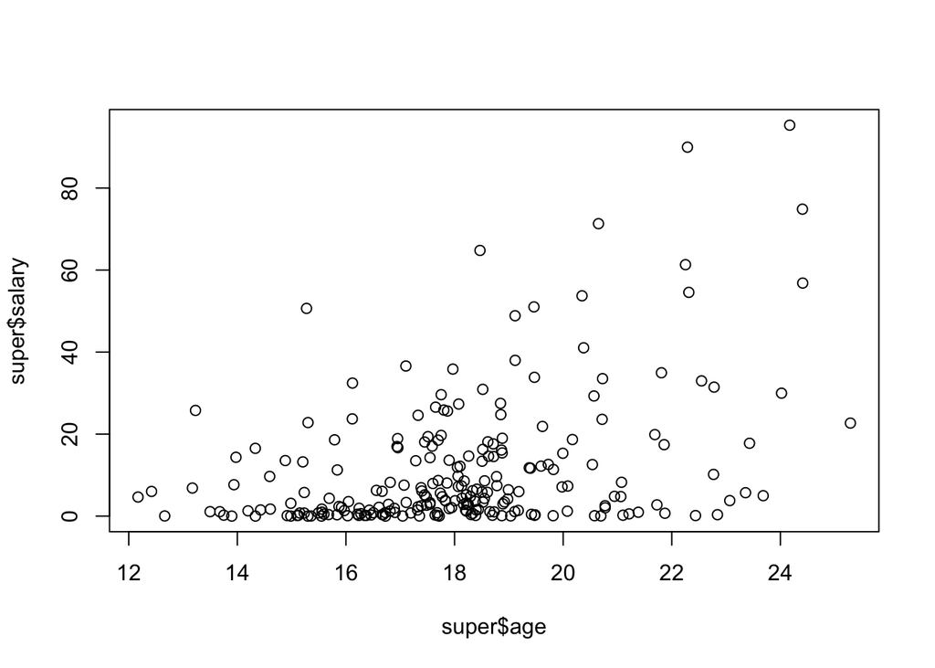

```r
plot(super$age,super$salary)
```

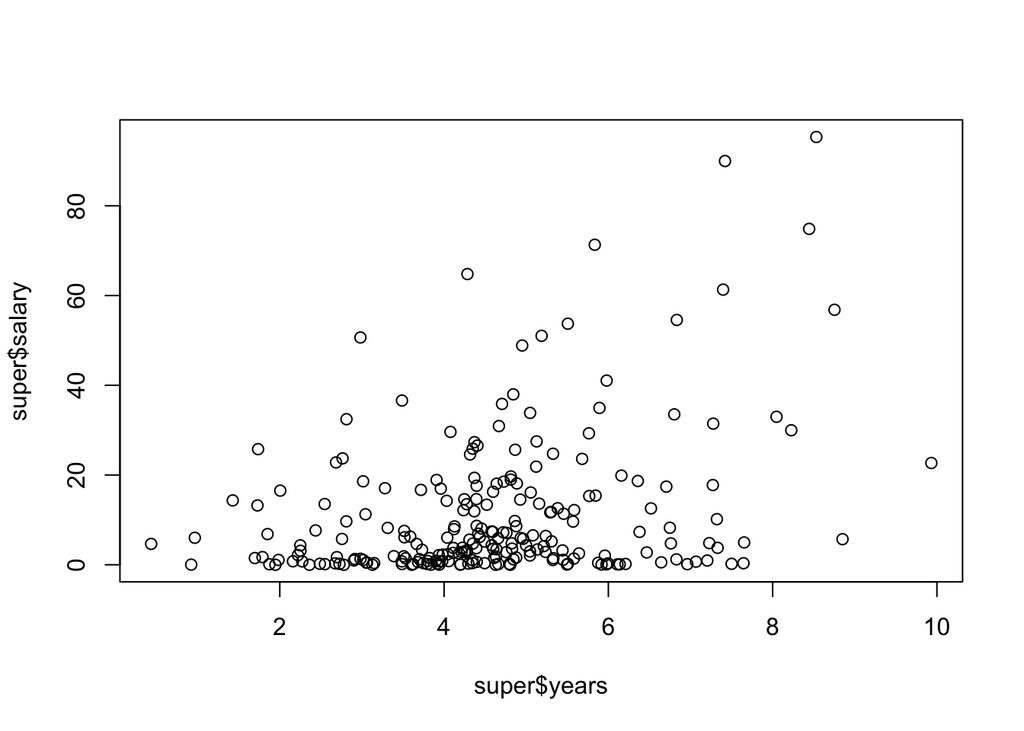

```r
plot(super$years,super$salary)
```

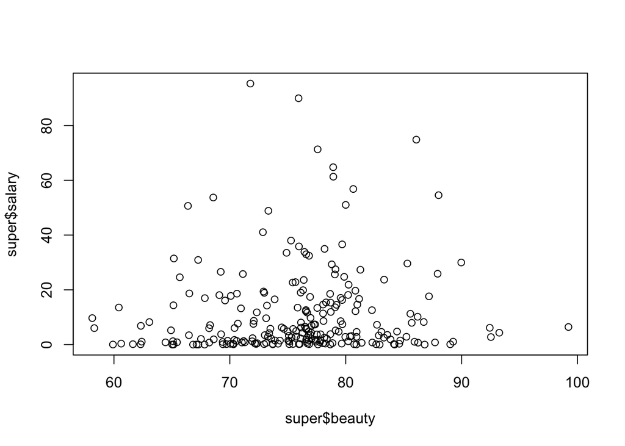

```r
plot(super$beauty,super$salary)
```

The first finding was that years of experience increases, salary decreases, is not what one would expect especially since age has a positive relationship with salary. Here in this output when we do years of experience as the only predictor, the relationship is positive. Using multiple predictors can influence the output of a regression model.